# Ford GoBike System Data

## Done by: Saad Alotaibi

## Introduction

> This data set is taken from ford go bike website and it represents trips taken by members of the service for month of February of 2019.

# Univariate Exploration

## PieChart of User Distribution

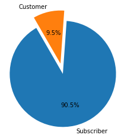

> Most users are subscribers (90.5% of total users) who are using the program more than actual customers who represents only 9.5% of total users.

# Histogram of Members birth year distribution

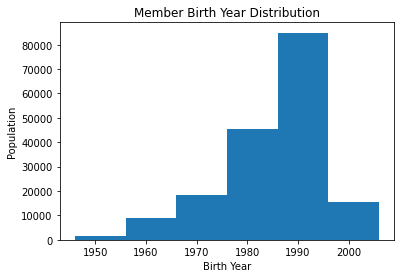

> As we can see that most of the users birth years are from 1975 to 1995

# Barchart of Gender

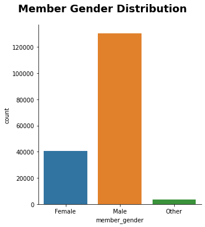

> From the barplot above we see the Males dominate this dataset and Females after, and the 'Other' are the lowest in bike usage

# Daily Usage Barchart

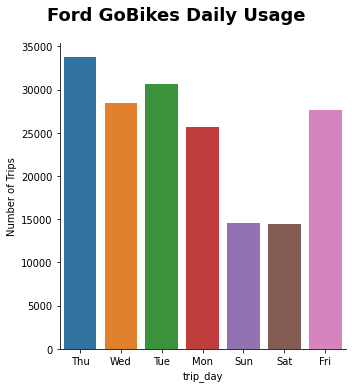

> It looks like the number of trips in most days are between 25,000 and roughly 33,000

> except in Sunday and Saturday which are lower

# Hourly Usage Distribution

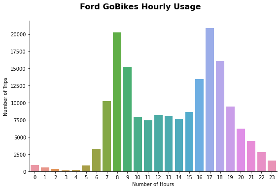

> From observing the peak-times of when users use the Ford GoBike System. The hours are mainly high between the morning from (8 AM) and in (17 and 18 which is 5 to 6 PM) in the afternoon.

# histogram of the duration bike rides in minutes

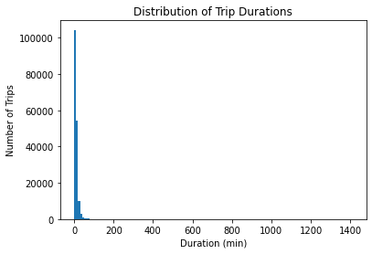

### now we have to transform it to make more understandable

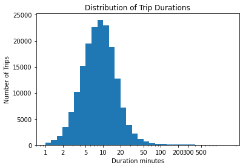

# Bivariate Exploration

# Boxplot of Duraction VS. Type of user

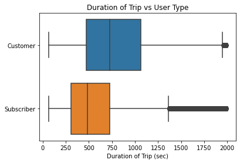

> Graphic shows that customers have more duration of trip than subscribers. Interesting! perhaps it was because it its their first experience and they wanted to ride longer?

# Gender VS. Duration in seconds

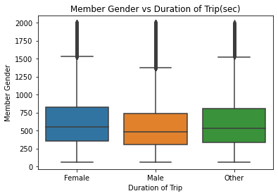

> Graphic shows that duration of trip distribution regarding to genders. Duration of trip is quite less for man gender but it is quite similar for female and others gender

# Scatter Age VS. trip duration (min)

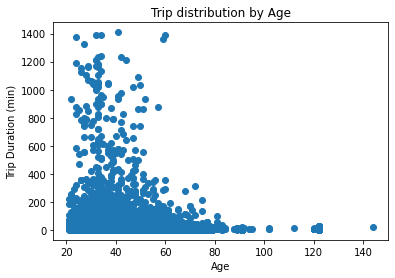

> Vast Majority of rides are for Users between ages 25 and 45 to 50 showing the inverse relationship between age and the trip duration.

# usage between Customers vs Subscribers

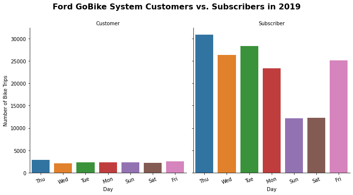

> As we can see the subscribers are way more using the bikes than the customers

# point plot customer VS. Subscriber

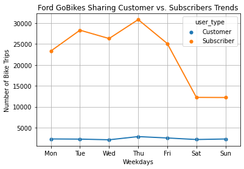

# Comparing Gender VS. type of user

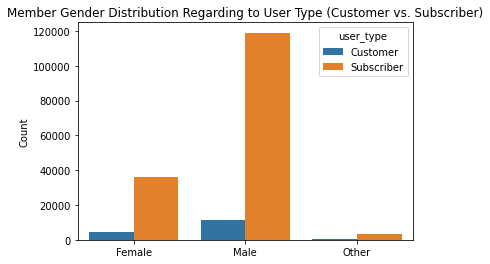

> Roughly 120.000 male members are subscriber. Subcribers are more than customers for male, female and other genders.

# Multivariate Exploration

# point plot of trip duration VS. gender

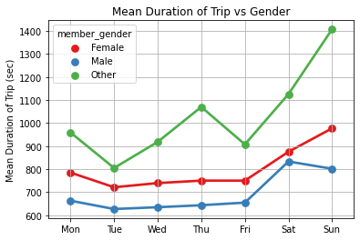

> As we can see that the 'Other' gender has the most fluctuation and an increase from Friday

> Male and Female are relatively stable compared to the 'Other' gender but all of them has an increase from Friday

# lmplot of Age VS. Duration of trip

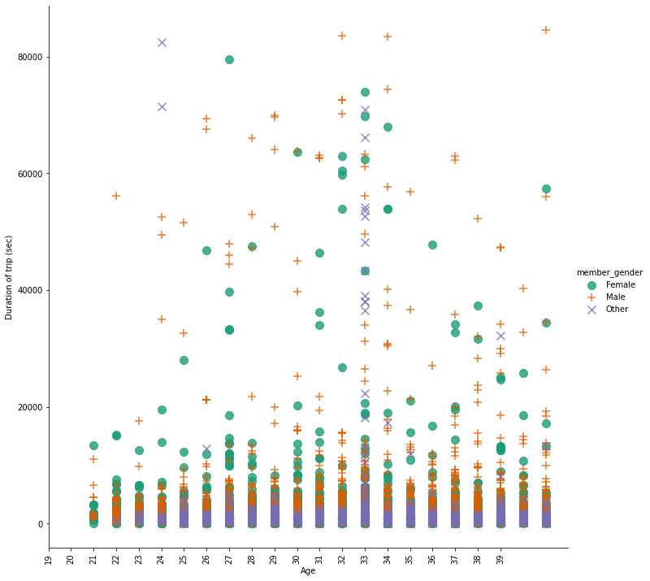

# Scatter plots of Age VS. gender and Duration (min)

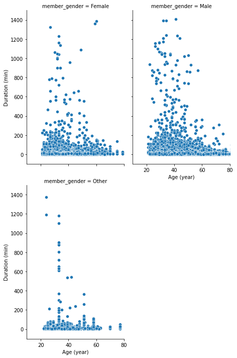

> Comparing the gender types as it relates to trip duration, the age 20 to 40 represents the group that does most of the rides.

> Females and males do appear to have similar ride average

# SUMMARY

- In this project, I got the data from udaicty data lists provided, I assessed and cleaned data at wrangling phase and prepared for analysis. Later I started analysis data step by step.
- Quality issues were mostly incorrect data types and there were some missing values. I decided to delete rows of missing information. Finally I started to analysis data.

### Univariate Plots

First I did univariate exploration. Here is my question to ask myself.

1. Users Distribution (pie chart): Subscribers were 90.5% while Customers are 9.5%
2. Member Birth year Distibution (histogram): Most of the users birth year were between 1975 to 1995
3. Gender Distribution (bar chart): Males are the majority of this dataset, females are second and lastly are 'Other'
4. Daily usage Distribution (bar chart): Least of the rides are on Sunday which is a weekend, and Saturday
5. hourly usage Distribution (count plot): hours are mainly high between 8 AM and 6 to 5 PM.

## Bivariate Plots

1. Duration VS. User Type (box plot): Customers have more duration of trip than subscribers.
2. Gender vs Duration in seconds (box plot): Duration of trip is quite less for the male gender but it is quite similar for female and others gender
3. Trip Duration (min) (scatter):Majority of rides are for Users between ages 25 and (45 - 50) showing an inverse relationship between age and the trip duration.
4. Customers vs. Subscribers Usage in days (bar chart): The subscribers are way more using the bikes than the customers